# Lab4

Author

Adaeze Obinelo

## Step 1

```r
library(tidyverse)
library(cowplot)
library(data.table)
library(dplyr)
met2 <-data.table::fread("met_all.gz")
str(met2)
```

```
Classes 'data.table' and 'data.frame':  2377343 obs. of  30 variables:
 $ USAFID           : int  690150 690150 690150 690150 690150 690150 690150 690150 690150 690150 ...
 $ WBAN             : int  93121 93121 93121 93121 93121 93121 93121 93121 93121 93121 ...
 $ year             : int  2019 2019 2019 2019 2019 2019 2019 2019 2019 2019 ...
 $ month            : int  8 8 8 8 8 8 8 8 8 8 ...
 $ day              : int  1 1 1 1 1 1 1 1 1 1 ...
 $ hour             : int  0 1 2 3 4 5 6 7 8 9 ...
 $ min              : int  56 56 56 56 56 56 56 56 56 56 ...
 $ lat              : num  34.3 34.3 34.3 34.3 34.3 34.3 34.3 34.3 34.3 34.3 ...
 $ lon              : num  -116 -116 -116 -116 -116 ...
 $ elev             : int  696 696 696 696 696 696 696 696 696 696 ...
 $ wind.dir         : int  220 230 230 210 120 NA 320 10 320 350 ...
 $ wind.dir.qc      : chr  "5" "5" "5" "5" ...
 $ wind.type.code   : chr  "N" "N" "N" "N" ...
 $ wind.sp          : num  5.7 8.2 6.7 5.1 2.1 0 1.5 2.1 2.6 1.5 ...
```

[output cut: 17 more lines]

```r
met2 <- met2[met2$temp > -17]

met2 %>%
  filter(!is.na(temp))
```

```
         USAFID  WBAN year month day hour min    lat      lon elev wind.dir
      1: 690150 93121 2019     8   1    0  56 34.300 -116.166  696      220
      2: 690150 93121 2019     8   1    1  56 34.300 -116.166  696      230
      3: 690150 93121 2019     8   1    2  56 34.300 -116.166  696      230
      4: 690150 93121 2019     8   1    3  56 34.300 -116.166  696      210
      5: 690150 93121 2019     8   1    4  56 34.300 -116.166  696      120
     ---
2317200: 726813 94195 2019     8  31   19  56 43.650 -116.633  741       70
2317201: 726813 94195 2019     8  31   20  56 43.650 -116.633  741       NA
2317202: 726813 94195 2019     8  31   21  56 43.650 -116.633  741       10
2317203: 726813 94195 2019     8  31   22  56 43.642 -116.636  741       10
2317204: 726813 94195 2019     8  31   23  56 43.642 -116.636  741       40
         wind.dir.qc wind.type.code wind.sp wind.sp.qc ceiling.ht ceiling.ht.qc
      1:           5              N     5.7          5      22000             5
      2:           5              N     8.2          5      22000             5
```

[output cut: 33 more lines]

```r
met2 %>%
  filter(!is.na(rh))
```

```
         USAFID  WBAN year month day hour min    lat      lon elev wind.dir
      1: 690150 93121 2019     8   1    0  56 34.300 -116.166  696      220
      2: 690150 93121 2019     8   1    1  56 34.300 -116.166  696      230
      3: 690150 93121 2019     8   1    2  56 34.300 -116.166  696      230
      4: 690150 93121 2019     8   1    3  56 34.300 -116.166  696      210
      5: 690150 93121 2019     8   1    4  56 34.300 -116.166  696      120
     ---
2310913: 726813 94195 2019     8  31   19  56 43.650 -116.633  741       70
2310914: 726813 94195 2019     8  31   20  56 43.650 -116.633  741       NA
2310915: 726813 94195 2019     8  31   21  56 43.650 -116.633  741       10
2310916: 726813 94195 2019     8  31   22  56 43.642 -116.636  741       10
2310917: 726813 94195 2019     8  31   23  56 43.642 -116.636  741       40
         wind.dir.qc wind.type.code wind.sp wind.sp.qc ceiling.ht ceiling.ht.qc
      1:           5              N     5.7          5      22000             5
      2:           5              N     8.2          5      22000             5
```

[output cut: 33 more lines]

```r
met2 %>%
  filter(!is.na(wind.sp))
```

```
         USAFID  WBAN year month day hour min    lat      lon elev wind.dir
      1: 690150 93121 2019     8   1    0  56 34.300 -116.166  696      220
      2: 690150 93121 2019     8   1    1  56 34.300 -116.166  696      230
      3: 690150 93121 2019     8   1    2  56 34.300 -116.166  696      230
      4: 690150 93121 2019     8   1    3  56 34.300 -116.166  696      210
      5: 690150 93121 2019     8   1    4  56 34.300 -116.166  696      120
     ---
2285457: 726813 94195 2019     8  31   19  56 43.650 -116.633  741       70
2285458: 726813 94195 2019     8  31   20  56 43.650 -116.633  741       NA
2285459: 726813 94195 2019     8  31   21  56 43.650 -116.633  741       10
2285460: 726813 94195 2019     8  31   22  56 43.642 -116.636  741       10
2285461: 726813 94195 2019     8  31   23  56 43.642 -116.636  741       40
         wind.dir.qc wind.type.code wind.sp wind.sp.qc ceiling.ht ceiling.ht.qc
      1:           5              N     5.7          5      22000             5
      2:           5              N     8.2          5      22000             5
```

[output cut: 33 more lines]

```r
met2 %>%
  filter(!is.na(vis.dist))
```

```
         USAFID  WBAN year month day hour min    lat      lon elev wind.dir
      1: 690150 93121 2019     8   1    0  56 34.300 -116.166  696      220
      2: 690150 93121 2019     8   1    1  56 34.300 -116.166  696      230
      3: 690150 93121 2019     8   1    2  56 34.300 -116.166  696      230
      4: 690150 93121 2019     8   1    3  56 34.300 -116.166  696      210
      5: 690150 93121 2019     8   1    4  56 34.300 -116.166  696      120
     ---
2283534: 726813 94195 2019     8  31   19  56 43.650 -116.633  741       70
2283535: 726813 94195 2019     8  31   20  56 43.650 -116.633  741       NA
2283536: 726813 94195 2019     8  31   21  56 43.650 -116.633  741       10
2283537: 726813 94195 2019     8  31   22  56 43.642 -116.636  741       10
2283538: 726813 94195 2019     8  31   23  56 43.642 -116.636  741       40
         wind.dir.qc wind.type.code wind.sp wind.sp.qc ceiling.ht ceiling.ht.qc
      1:           5              N     5.7          5      22000             5
      2:           5              N     8.2          5      22000             5
```

[output cut: 33 more lines]

```r
met2 %>%
  filter(!is.na(dew.point))
```

```
         USAFID  WBAN year month day hour min    lat      lon elev wind.dir
      1: 690150 93121 2019     8   1    0  56 34.300 -116.166  696      220
      2: 690150 93121 2019     8   1    1  56 34.300 -116.166  696      230
      3: 690150 93121 2019     8   1    2  56 34.300 -116.166  696      230
      4: 690150 93121 2019     8   1    3  56 34.300 -116.166  696      210
      5: 690150 93121 2019     8   1    4  56 34.300 -116.166  696      120
     ---
2310913: 726813 94195 2019     8  31   19  56 43.650 -116.633  741       70
2310914: 726813 94195 2019     8  31   20  56 43.650 -116.633  741       NA
2310915: 726813 94195 2019     8  31   21  56 43.650 -116.633  741       10
2310916: 726813 94195 2019     8  31   22  56 43.642 -116.636  741       10
2310917: 726813 94195 2019     8  31   23  56 43.642 -116.636  741       40
         wind.dir.qc wind.type.code wind.sp wind.sp.qc ceiling.ht ceiling.ht.qc
      1:           5              N     5.7          5      22000             5
      2:           5              N     8.2          5      22000             5
```

[output cut: 33 more lines]

```r
met2 %>%
  filter(!is.na(lat))
```

```
         USAFID  WBAN year month day hour min    lat      lon elev wind.dir
      1: 690150 93121 2019     8   1    0  56 34.300 -116.166  696      220
      2: 690150 93121 2019     8   1    1  56 34.300 -116.166  696      230
      3: 690150 93121 2019     8   1    2  56 34.300 -116.166  696      230
      4: 690150 93121 2019     8   1    3  56 34.300 -116.166  696      210
      5: 690150 93121 2019     8   1    4  56 34.300 -116.166  696      120
     ---
2317200: 726813 94195 2019     8  31   19  56 43.650 -116.633  741       70
2317201: 726813 94195 2019     8  31   20  56 43.650 -116.633  741       NA
2317202: 726813 94195 2019     8  31   21  56 43.650 -116.633  741       10
2317203: 726813 94195 2019     8  31   22  56 43.642 -116.636  741       10
2317204: 726813 94195 2019     8  31   23  56 43.642 -116.636  741       40
         wind.dir.qc wind.type.code wind.sp wind.sp.qc ceiling.ht ceiling.ht.qc
      1:           5              N     5.7          5      22000             5
      2:           5              N     8.2          5      22000             5
```

[output cut: 33 more lines]

```r
met2 %>%
  filter(!is.na(lon))
```

```
         USAFID  WBAN year month day hour min    lat      lon elev wind.dir
      1: 690150 93121 2019     8   1    0  56 34.300 -116.166  696      220
      2: 690150 93121 2019     8   1    1  56 34.300 -116.166  696      230
      3: 690150 93121 2019     8   1    2  56 34.300 -116.166  696      230
      4: 690150 93121 2019     8   1    3  56 34.300 -116.166  696      210
      5: 690150 93121 2019     8   1    4  56 34.300 -116.166  696      120
     ---
2317200: 726813 94195 2019     8  31   19  56 43.650 -116.633  741       70
2317201: 726813 94195 2019     8  31   20  56 43.650 -116.633  741       NA
2317202: 726813 94195 2019     8  31   21  56 43.650 -116.633  741       10
2317203: 726813 94195 2019     8  31   22  56 43.642 -116.636  741       10
2317204: 726813 94195 2019     8  31   23  56 43.642 -116.636  741       40
         wind.dir.qc wind.type.code wind.sp wind.sp.qc ceiling.ht ceiling.ht.qc
      1:           5              N     5.7          5      22000             5
      2:           5              N     8.2          5      22000             5
```

[output cut: 33 more lines]

```r
met2 %>%
  filter(!is.na(elev))
```

```
         USAFID  WBAN year month day hour min    lat      lon elev wind.dir
      1: 690150 93121 2019     8   1    0  56 34.300 -116.166  696      220
      2: 690150 93121 2019     8   1    1  56 34.300 -116.166  696      230
      3: 690150 93121 2019     8   1    2  56 34.300 -116.166  696      230
      4: 690150 93121 2019     8   1    3  56 34.300 -116.166  696      210
      5: 690150 93121 2019     8   1    4  56 34.300 -116.166  696      120
     ---
2317200: 726813 94195 2019     8  31   19  56 43.650 -116.633  741       70
2317201: 726813 94195 2019     8  31   20  56 43.650 -116.633  741       NA
2317202: 726813 94195 2019     8  31   21  56 43.650 -116.633  741       10
2317203: 726813 94195 2019     8  31   22  56 43.642 -116.636  741       10
2317204: 726813 94195 2019     8  31   23  56 43.642 -116.636  741       40
         wind.dir.qc wind.type.code wind.sp wind.sp.qc ceiling.ht ceiling.ht.qc
      1:           5              N     5.7          5      22000             5
      2:           5              N     8.2          5      22000             5
```

[output cut: 33 more lines]

```r
summary(met2$rh)
```

```
   Min. 1st Qu.  Median    Mean 3rd Qu.    Max.    NA's
  0.833  55.790  76.554  71.641  90.629 100.000    6287
```

```r
summary(met2$wind.sp)
```

```
   Min. 1st Qu.  Median    Mean 3rd Qu.    Max.    NA's
   0.00    0.00    2.10    2.46    3.60   36.00   31743
```

```r
summary(met2$vis.dist)
```

```
   Min. 1st Qu.  Median    Mean 3rd Qu.    Max.    NA's
      0   16093   16093   14924   16093  160000   33666
```

```r
summary(met2$dew.point)
```

```
   Min. 1st Qu.  Median    Mean 3rd Qu.    Max.    NA's
 -37.20   13.80   18.10   17.02   21.70   36.00    6287
```

```r
summary(met2$lat)
```

```
   Min. 1st Qu.  Median    Mean 3rd Qu.    Max.
  24.55   33.98   38.37   37.97   41.96   48.94
```

```r
summary(met2$lon)
```

```
   Min. 1st Qu.  Median    Mean 3rd Qu.    Max.
-124.29  -98.02  -91.74  -92.14  -82.99  -68.31
```

```r
summary(met2)
```

```
     USAFID            WBAN            year          month        day
 Min.   :690150   Min.   :  116   Min.   :2019   Min.   :8   Min.   : 1
 1st Qu.:720927   1st Qu.: 3705   1st Qu.:2019   1st Qu.:8   1st Qu.: 8
 Median :722720   Median :13841   Median :2019   Median :8   Median :16
 Mean   :723095   Mean   :29496   Mean   :2019   Mean   :8   Mean   :16
 3rd Qu.:725090   3rd Qu.:54768   3rd Qu.:2019   3rd Qu.:8   3rd Qu.:24
 Max.   :726813   Max.   :94998   Max.   :2019   Max.   :8   Max.   :31

      hour            min             lat             lon
 Min.   : 0.00   Min.   : 0.00   Min.   :24.55   Min.   :-124.29
 1st Qu.: 6.00   1st Qu.:20.00   1st Qu.:33.98   1st Qu.: -98.02
 Median :11.00   Median :48.00   Median :38.37   Median : -91.74
 Mean   :11.46   Mean   :39.23   Mean   :37.97   Mean   : -92.14
 3rd Qu.:17.00   3rd Qu.:55.00   3rd Qu.:41.96   3rd Qu.: -82.99
 Max.   :23.00   Max.   :59.00   Max.   :48.94   Max.   : -68.31

      elev           wind.dir      wind.dir.qc        wind.type.code
 Min.   : -13.0   Min.   :  3      Length:2317204     Length:2317204
 1st Qu.: 101.0   1st Qu.:120      Class :character   Class :character
 Median : 252.0   Median :180      Mode  :character   Mode  :character
 Mean   : 415.1   Mean   :185
 3rd Qu.: 400.0   3rd Qu.:260
 Max.   :9999.0   Max.   :360
                  NA's   :732170
    wind.sp       wind.sp.qc          ceiling.ht    ceiling.ht.qc
 Min.   : 0.00   Length:2317204     Min.   :    0   Min.   :1.000
 1st Qu.: 0.00   Class :character   1st Qu.: 3048   1st Qu.:5.000
 Median : 2.10   Mode  :character   Median :22000   Median :5.000
 Mean   : 2.46                      Mean   :16171   Mean   :4.945
 3rd Qu.: 3.60                      3rd Qu.:22000   3rd Qu.:5.000
 Max.   :36.00                      Max.   :22000   Max.   :9.000
 NA's   :31743                      NA's   :73437
 ceiling.ht.method    sky.cond            vis.dist      vis.dist.qc
 Length:2317204     Length:2317204     Min.   :     0   Length:2317204
 Class :character   Class :character   1st Qu.: 16093   Class :character
 Mode  :character   Mode  :character   Median : 16093   Mode  :character
                                       Mean   : 14924
                                       3rd Qu.: 16093
                                       Max.   :160000
                                       NA's   :33666
```

[output cut: 9 more lines]

```
 Min.   :-37.20   Length:2317204     Min.   : 960.5    Min.   :1.000
 1st Qu.: 13.80   Class :character   1st Qu.:1011.8    1st Qu.:5.000
 Median : 18.10   Mode  :character   Median :1014.1    Median :9.000
 Mean   : 17.02                      Mean   :1014.2    Mean   :7.696
 3rd Qu.: 21.70                      3rd Qu.:1016.4    3rd Qu.:9.000
 Max.   : 36.00                      Max.   :1059.9    Max.   :9.000
 NA's   :6287                        NA's   :1606783
       rh
 Min.   :  0.833
 1st Qu.: 55.790
 Median : 76.554
 Mean   : 71.641
 3rd Qu.: 90.629
 Max.   :100.000
 NA's   :6287
```

```r
met2_no_NA <- na.omit(met2)
```

## Step 2

NA’s removed in step 1 and 2 to this dataset

```r
met2_no_NA$Date <- as.Date(paste(met2_no_NA$year, met2_no_NA$month, met2_no_NA$day, sep = "-"))
met2_no_NA$week <- data.table(week(met2_no_NA$Date))
filter(met2_no_NA, week <32 & day < 7)
```

```
       USAFID  WBAN year month day hour min   lat      lon elev wind.dir
    1: 690150 93121 2019     8   1    0  56 34.30 -116.166  696      220
    2: 690150 93121 2019     8   1    1  56 34.30 -116.166  696      230
    3: 690150 93121 2019     8   1    2  56 34.30 -116.166  696      230
    4: 690150 93121 2019     8   1    3  56 34.30 -116.166  696      210
    5: 690150 93121 2019     8   1    4  56 34.30 -116.166  696      120
   ---
58277: 726813 94195 2019     8   4   17  56 43.65 -116.633  741       10
58278: 726813 94195 2019     8   4   18  56 43.65 -116.633  741      330
58279: 726813 94195 2019     8   4   19  56 43.65 -116.633  741       40
58280: 726813 94195 2019     8   4   20  56 43.65 -116.633  741       50
58281: 726813 94195 2019     8   4   21  56 43.65 -116.633  741       30
       wind.dir.qc wind.type.code wind.sp wind.sp.qc ceiling.ht ceiling.ht.qc
    1:           5              N     5.7          5      22000             5
    2:           5              N     8.2          5      22000             5
```

[output cut: 45 more lines]

```r
met_avg <- met2_no_NA[,.(
  temp     = mean(temp,na.rm=TRUE),
  rh       = mean(rh,na.rm=TRUE),
  wind.sp  = mean(wind.sp,na.rm=TRUE),
  vis.dist = mean(vis.dist,na.rm=TRUE),
  dew.point = mean(dew.point,na.rm=TRUE),
  lat      = mean(lat),
  lon      = mean(lon),
  elev     = mean(elev,na.rm=TRUE)
), by=c("USAFID", "day")]

met_avg[, region   := fifelse(lon > -98, "east", "west")]
met_avg[, elev_cat := fifelse(elev > 252, "high", "low")]
```

## Step 3

NA’s removed in step 1 and 2 to this dataset

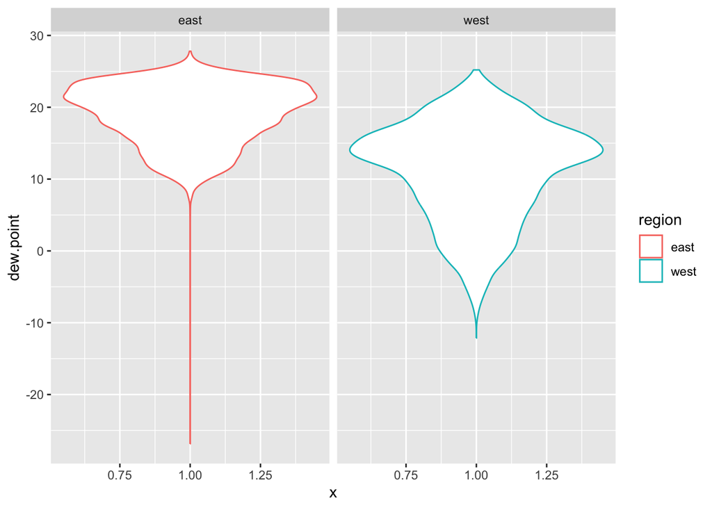

```r
ggplot(met_avg, aes(y = dew.point, x = 1, color = region)) +
  geom_violin(scale = "count") +
  facet_wrap(~region)
```

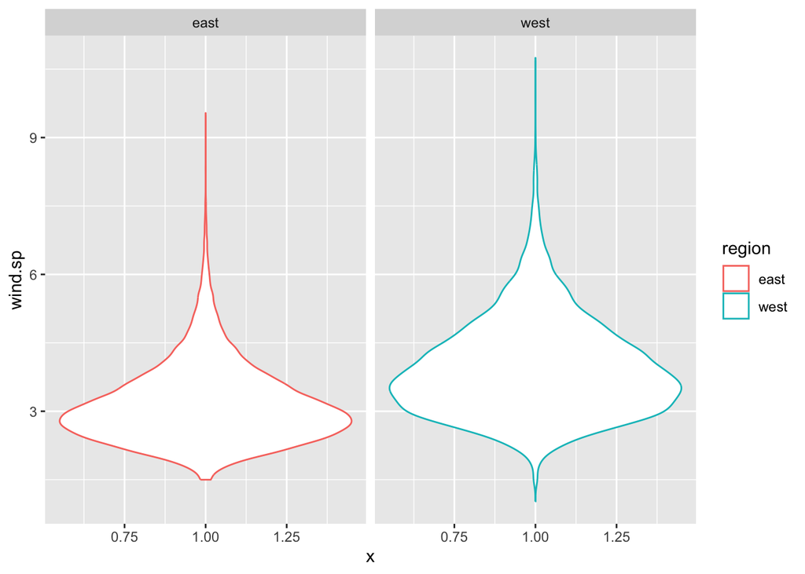

```r
ggplot(met_avg, aes(y = wind.sp, x = 1, color = region)) +
  geom_violin(scale = "count") +
  facet_wrap(~region)
```

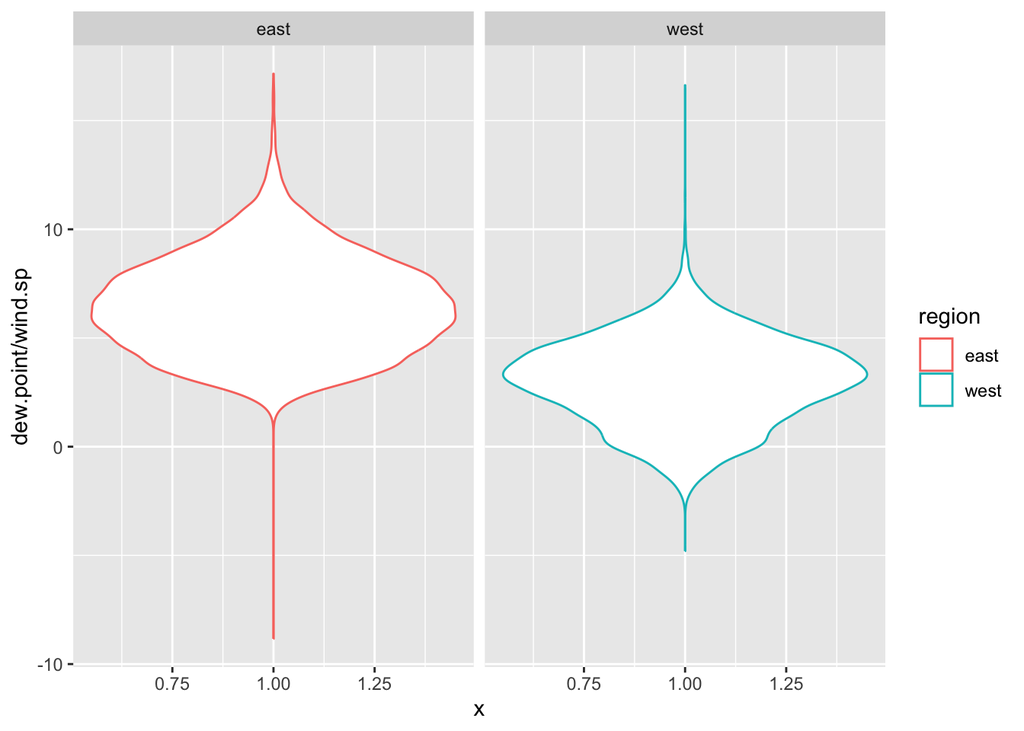

```r
ggplot(met_avg, aes(y = dew.point / wind.sp, x = 1, color = region)) +
  geom_violin(scale = "count") +
  facet_wrap(~region)
```

Plot 1 and 2: By setting x to 1, violin plot areas correspond directly to the frequency of observations in the two regions. In plot 2, this area corresponds to frequency of average wind speeds and in 1, the frequency of average dew points. We see that in the East the wind speed tends to be lower and the dew point tends to be higher compared to the case in the west.